# Two-sample T-test

## The study

Among calf raisers there is a strong preference for calving time. The vast majority favor winter births so that the weaning period coincides with the beginning of spring. The reasons given by breeders are diverse, one of them being that calves born in winter reach a higher weight at weaning than those born in summer, which makes production at this time more attractive.

Similarly, we would like to know if the same can be concluded for the breeding of foals to be used in high performance sports. In this case, having smaller foals could generate an advantage when selecting them for sports in which agility is an important factor.

For this purpose, we collected data from 400 births in Quarter Horse farms in Argentina, for the period 2020 - 2021. The data have been tabulated detailing the weight of the foal at birth. Each foal was assigned a group, depending on the season of the year in which they were born. The sample consisted of two groups, with 210 foals born in summer (grupo 1) and 190 in winter (grupo 2).

*Please have in mind all this context is fictional.*

## Loading data

```r
library(dplyr)
library(ggplot2)
```

```r
data <- read.csv("data/datos21.txt", header = FALSE, sep = "\t", col.names = c('weight', 'group'))

head(data)
```

```
##   weight  group
## 1   46.3 grupo1
## 2   48.3 grupo1
## 3   55.1 grupo1
## 4   56.0 grupo1
## 5   46.7 grupo1
## 6   45.5 grupo1
```

## Descriptive statictics

First of all, we’ll get a summary for each sample.

```r
data %>% group_by(group) %>%
  summarise(min = min(weight),
            max = max(weight),
            mean = mean(weight),
            sd = sd(weight),
            n = n(),
            q1 = quantile(weight, .25),
            q3 = quantile(weight, .75))
```

```
## # A tibble: 2 × 8
##   group    min   max  mean    sd     n    q1    q3
##   <chr>  <dbl> <dbl> <dbl> <dbl> <int> <dbl> <dbl>
## 1 grupo1  41.5  58.5  50.3  3.01   210  48.1  52.4
## 2 grupo2  52.5  67    60.1  2.99   190  58    62.1
```

It can be observed that the mean weight in grupo2 (winter) is 10 kg higher than for grupo1 (summer). For both samples the median value is close to the mean, suggesting that the data is approximately centered to the middle values. The standard deviations are very similar for both samples, indicating that they differ similarly from their mean.

We could observe the same using a boxplot.

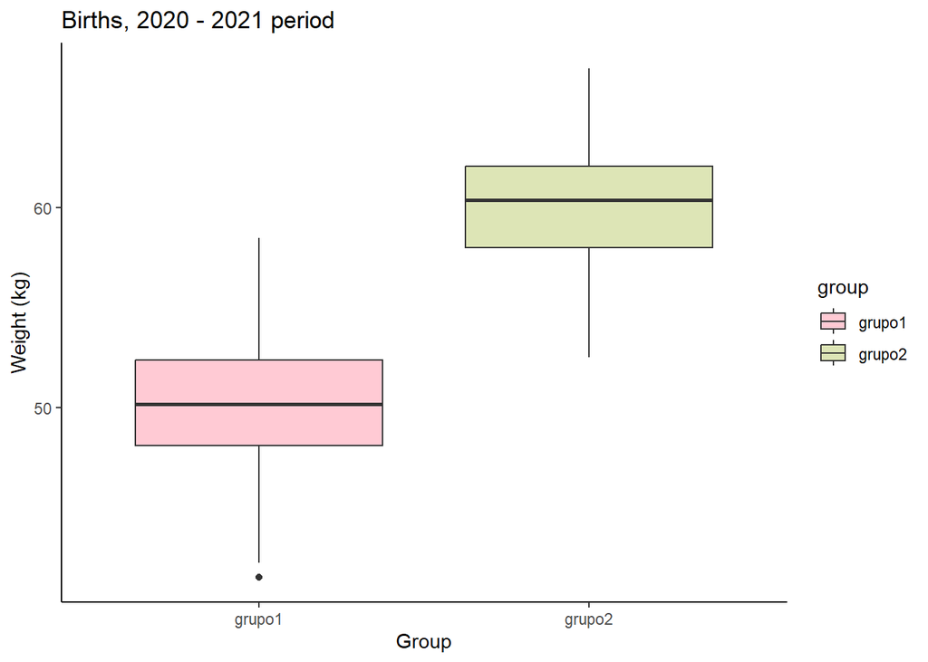

```r
data %>% ggplot(aes(x=group, y=weight, fill=group)) +
  geom_boxplot() +
  scale_fill_manual(values = c("#ffcad4", "#dde5b6")) +
  labs(
    title = "Births, 2020 - 2021 period",
    x = "Group",
    y = "Weight (kg)"
  ) +
  theme_classic()
```

Here we can also notice more grafically that extreme minimum weights were recorded in summer. In addition, it is evident that the minimum values of the group of foals born in winter overlaps with the maximum values of those born in summer.

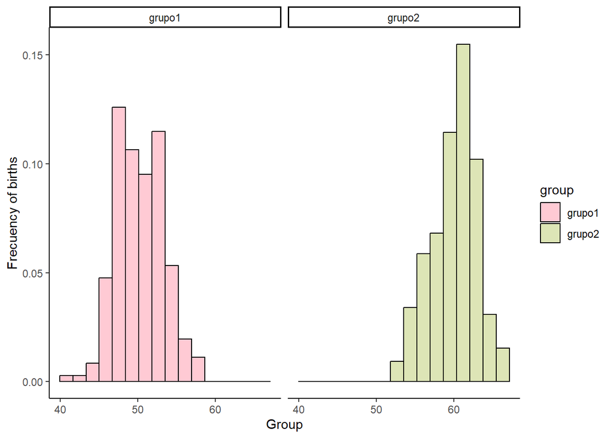

```r
data %>%
  ggplot( aes(x=weight, color=group, fill=group)) +
    geom_histogram(aes(y=after_stat(density)),bins=16, colour = 1) +
    scale_fill_manual(values = c("#ffcad4", "#dde5b6")) +
    xlab("Group") +
    ylab("Frecuency of births") +
    facet_wrap(~group) +
    theme_classic()
```

The histograms allow us to see at a glance the distribution of the data.

The left one indicates that the sample of foals born in summer has no skew. The right one, for foals born in winter, has a negative skew.

A priori, we could tell there is a tendency to obtain smaller foals if they are born at higher temperatures.

## Hypothesis

Null: No differences are observed in the average weight of foals born at different times of the year. Those born in summer weigh the same as those born in winter.

$\mu_{S} - \mu_{W} = 0$

Alternative: Differences are observed in the average weight of foals born at different times of the year, with those born in summer being less heavy than those born in winter.

$\mu_{S} - \mu_{W} < 0$

Being

$\mu_{S}$ : Mean weight in kilograms of foals born in summer

$\mu_{W}$ : Mean weight in kilograms of foals born in winter

## Hypothesis test

```r
summer <- filter(data, group == "grupo1") %>% select(weight) %>% unlist
winter <- filter(data, group == "grupo2") %>% select(weight) %>% unlist
```

### Testing for Normality

For two independent samples it is assumed that the observations within each category are normally distributed.

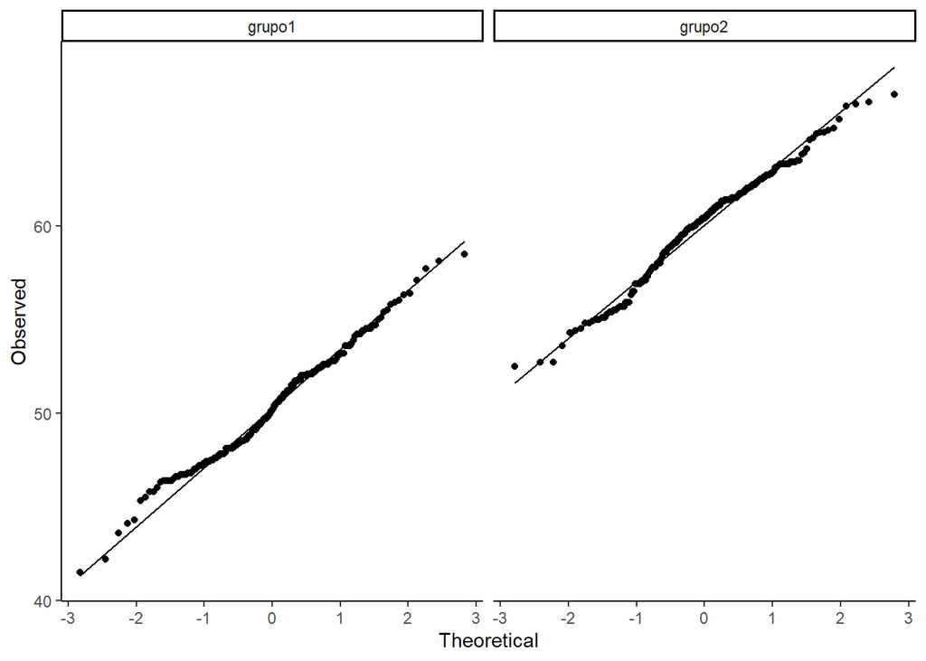

```r
data %>% ggplot(aes(sample = weight)) +
  stat_qq() +
  stat_qq_line() +
  xlab("Theoretical") +
  ylab("Observed") +
  facet_wrap(~group) +
  theme_classic()
```

To corroborate that the assumption is met, “q-q normal” plots are made for both categories. It is observed that the samples fit the normal distribution, showing a very strong linear association between the observed and expected quantiles.

### Results

```r
t.test(
  x = summer,
  y = winter,
  alternative="less",
  mu = 0,
  paired=FALSE,
  var.equal=TRUE,
  conf.level=0.95
  )
```

```
##
##  Two Sample t-test
##
## data:  summer and winter
## t = -32.573, df = 398, p-value < 2.2e-16
## alternative hypothesis: true difference in means is less than 0
## 95 percent confidence interval:
##       -Inf -9.292307
## sample estimates:
## mean of x mean of y
##  50.28333  60.07105
```

Having obtained the value of the test statistic $t=-32.57$ and the degrees of freedom $df = 398$, the test showed a $p-value<0.0001$. Comparing it to the conventionally accepted level of significance ($\alpha=0.05$) we can say that the test was extremely significant and we are in position to reject our null hypothesis. The sample, then, provides significant evidence that the average weight of summer-born foals is lower than the average weight of winter-born foals.

We can also see that the confidence interval is significant and does not include zero.

A graph visually comparing the means of the two samples is shown below.

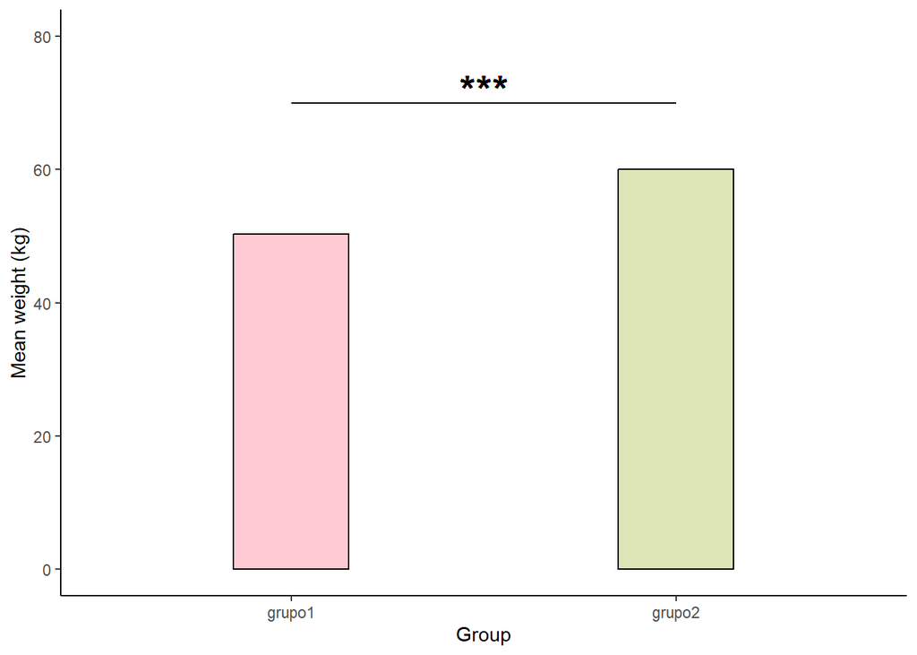

```r
data %>% ggplot(aes(y=weight, x=group)) +
  stat_summary(
    fun = mean,
    geom = "bar",
    color = "black",
    width = .3,
    fill = c("#ffcad4", "#dde5b6")) +
  ylim(0, 80) +
  geom_segment(
    x = 1,
    y = 70,
    xend = 2,
    yend = 70
  ) +
  geom_text(
    x = 1.5,
    y = 72,
    label = "***",
    size = 8
  ) +
  theme_classic() +
  labs(
    x = "Group",
    y = "Mean weight (kg)"
  )
```

Since the null hypothesis is rejected, there is a possibility of committing type I error, concluding that the average weight in summer is lower than in winter, having in fact obtained this result by chance. However, the probability of making this error is very low, less than 0.0001.

## Conclusion

We can conclude that in order to produce smaller horses for use in agility sports, summer births should be favored, since there is a tendency to obtain lower weights in the summer period.